# 1.2 Logistic Regression - Practice

## Logistic Regression Lecture

For this lecture we will be working with the Titanic Data Set from Kaggle. This is a very famous data set and very often is a student’s first step in machine learning! We’ll be trying to predict a classification- survival or deceased.

Let’s begin our understanding of implementing Logistic Regression in R for classification.

We’ll use a “semi-cleaned” version of the titanic data set, if you use the data set hosted directly on Kaggle, you may need to do some additional cleaning not shown in this lecture notebook.

## The Data

We can begin by loading in our training data into data frames:

```r
df.train <- read.csv('titanic_train.csv')
head(df.train)
```

```
##   PassengerId Survived Pclass
## 1           1        0      3
## 2           2        1      1
## 3           3        1      3
## 4           4        1      1
## 5           5        0      3
## 6           6        0      3
##                                                  Name    Sex Age SibSp
## 1                             Braund, Mr. Owen Harris   male  22     1
## 2 Cumings, Mrs. John Bradley (Florence Briggs Thayer) female  38     1
## 3                              Heikkinen, Miss. Laina female  26     0
## 4        Futrelle, Mrs. Jacques Heath (Lily May Peel) female  35     1
## 5                            Allen, Mr. William Henry   male  35     0
## 6                                    Moran, Mr. James   male  NA     0
##   Parch           Ticket    Fare Cabin Embarked
## 1     0        A/5 21171  7.2500              S
## 2     0         PC 17599 71.2833   C85        C
## 3     0 STON/O2. 3101282  7.9250              S
## 4     0           113803 53.1000  C123        S
## 5     0           373450  8.0500              S
## 6     0           330877  8.4583              Q
```

```r
print(str(df.train))
```

```
## 'data.frame':    891 obs. of  12 variables:
##  $ PassengerId: int  1 2 3 4 5 6 7 8 9 10 ...
##  $ Survived   : int  0 1 1 1 0 0 0 0 1 1 ...
##  $ Pclass     : int  3 1 3 1 3 3 1 3 3 2 ...
##  $ Name       : Factor w/ 891 levels "Abbing, Mr. Anthony",..: 109 191 358 277 16 559 520 629 417 581 ...
##  $ Sex        : Factor w/ 2 levels "female","male": 2 1 1 1 2 2 2 2 1 1 ...
##  $ Age        : num  22 38 26 35 35 NA 54 2 27 14 ...
##  $ SibSp      : int  1 1 0 1 0 0 0 3 0 1 ...
##  $ Parch      : int  0 0 0 0 0 0 0 1 2 0 ...
##  $ Ticket     : Factor w/ 681 levels "110152","110413",..: 524 597 670 50 473 276 86 396 345 133 ...
##  $ Fare       : num  7.25 71.28 7.92 53.1 8.05 ...
##  $ Cabin      : Factor w/ 148 levels "","A10","A14",..: 1 83 1 57 1 1 131 1 1 1 ...
##  $ Embarked   : Factor w/ 4 levels "","C","Q","S": 4 2 4 4 4 3 4 4 4 2 ...
## NULL
```

## Exploratory Data Analysis (EDA)

```r
# Library to check missing data easily
library(Amelia)
```

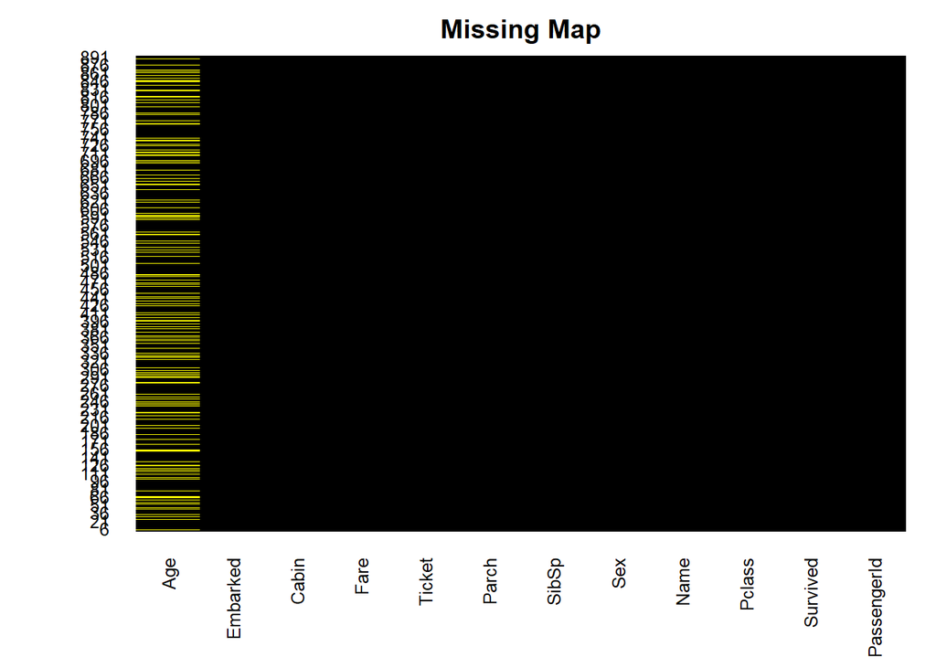

```r
missmap(df.train, main = 'Missing Map', col = c('yellow','black'), legend = FALSE)
```

## Data Visualization with ggplot2

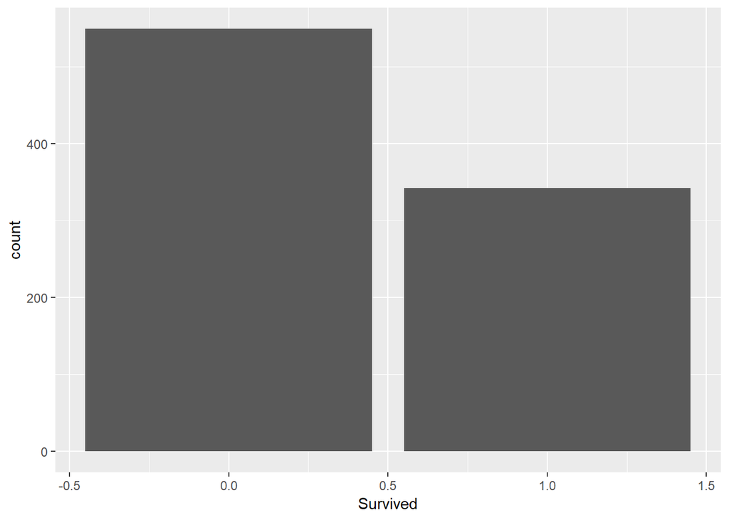

```r
library(ggplot2)
ggplot(df.train,aes(Survived)) + geom_bar()
```

By class

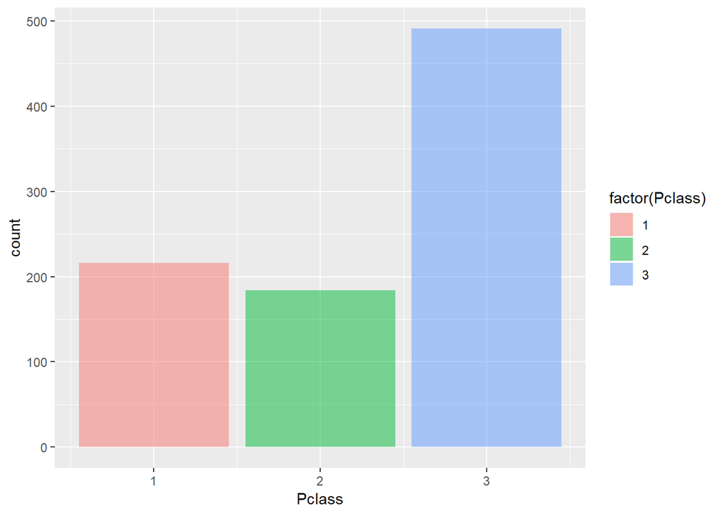

```r
ggplot(df.train,aes(Pclass)) + geom_bar(aes(fill=factor(Pclass)),alpha=0.5)
```

By gender

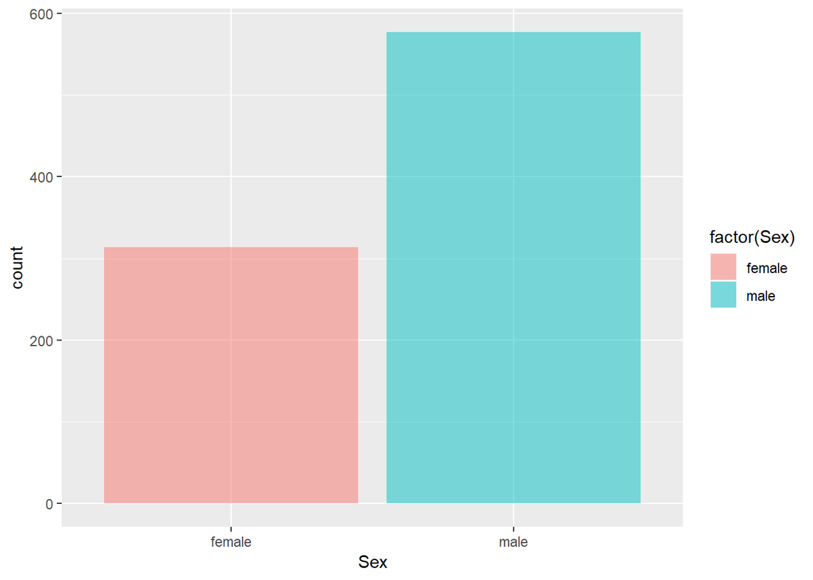

```r
ggplot(df.train,aes(Sex)) + geom_bar(aes(fill=factor(Sex)),alpha=0.5)
```

By age

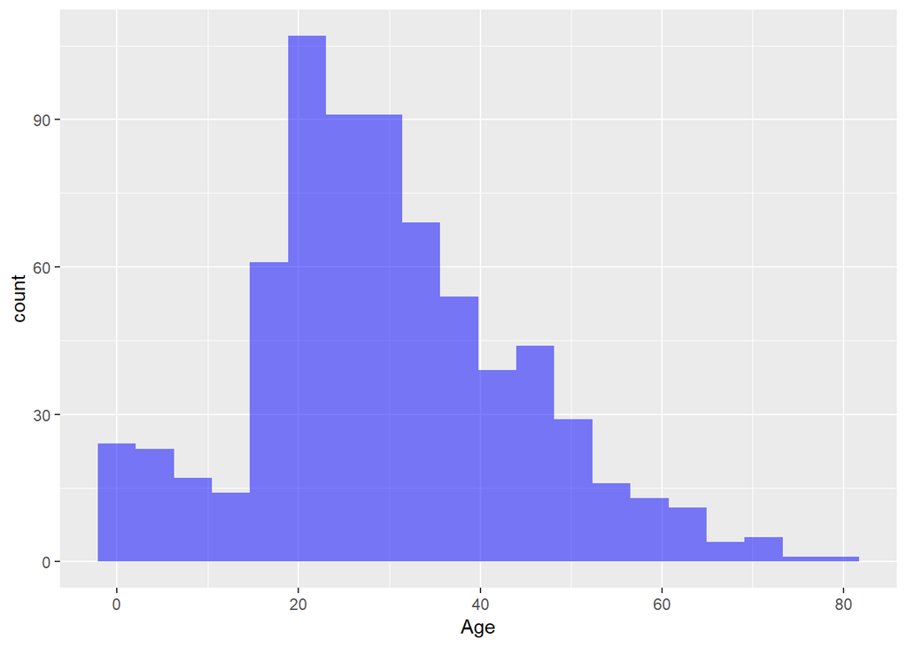

```r
ggplot(df.train,aes(Age)) + geom_histogram(fill='blue',bins=20,alpha=0.5)
```

By Sibling, spouse

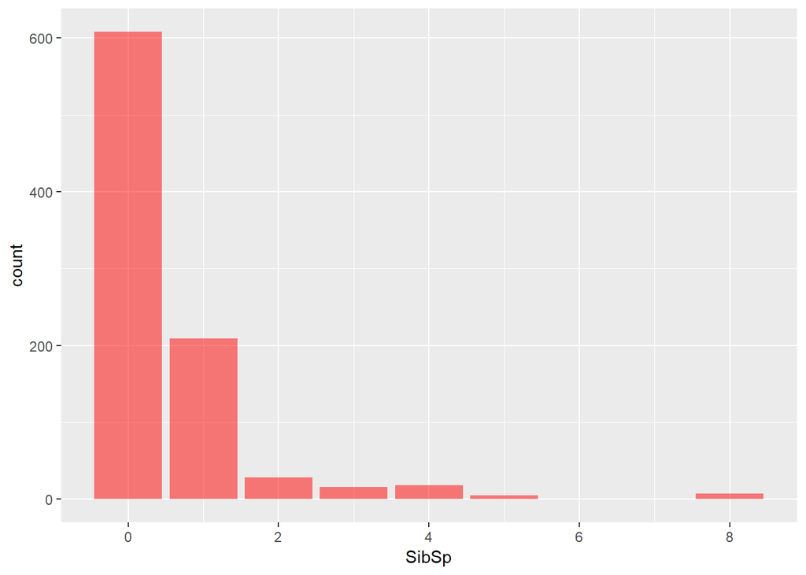

```r
ggplot(df.train,aes(SibSp)) + geom_bar(fill='red',alpha=0.5)
```

By fare

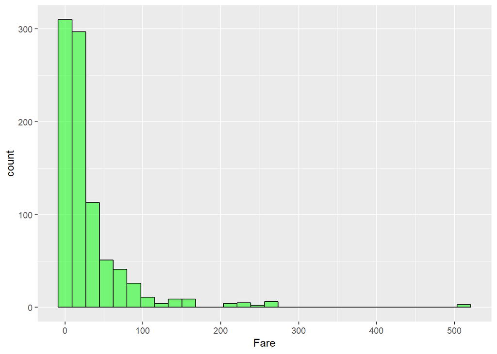

```r
ggplot(df.train,aes(Fare)) + geom_histogram(fill='green',color='black',alpha=0.5)
```

## Data Cleaning

We want to fill in missing age data instead of just dropping the missing age data rows. One way to do this is by filling in the mean age of all the passengers (imputation).

However we can be smarter about this and check the average age by passenger class. For example:

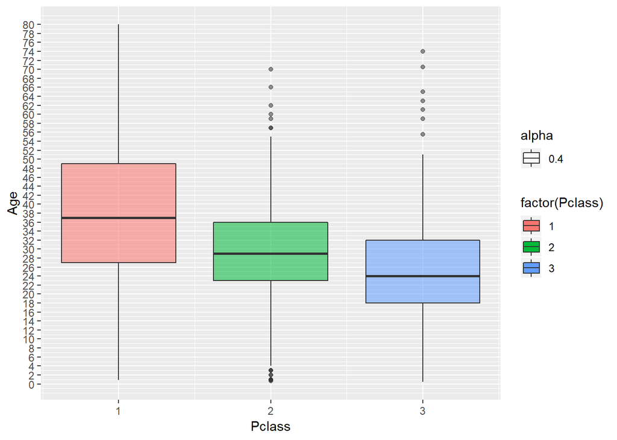

```r
pl <- ggplot(df.train,aes(Pclass,Age)) + geom_boxplot(aes(group=Pclass,fill=factor(Pclass),alpha=0.4))
pl + scale_y_continuous(breaks = seq(min(0), max(80), by = 2))
```

We can see the wealthier passengers in the higher classes tend to be older, which makes sense. We’ll use these average age values to impute based on Pclass for Age.

```r
impute_age <- function(age,class){
    out <- age
    for (i in 1:length(age)){

        if (is.na(age[i])){

            if (class[i] == 1){
                out[i] <- 37

            }else if (class[i] == 2){
                out[i] <- 29

            }else{
                out[i] <- 24
            }
        }else{
            out[i]<-age[i]
        }
    }
    return(out)
}

fixed.ages <- impute_age(df.train$Age,df.train$Pclass)
df.train$Age <- fixed.ages
```

Now let’s check to see if it worked:

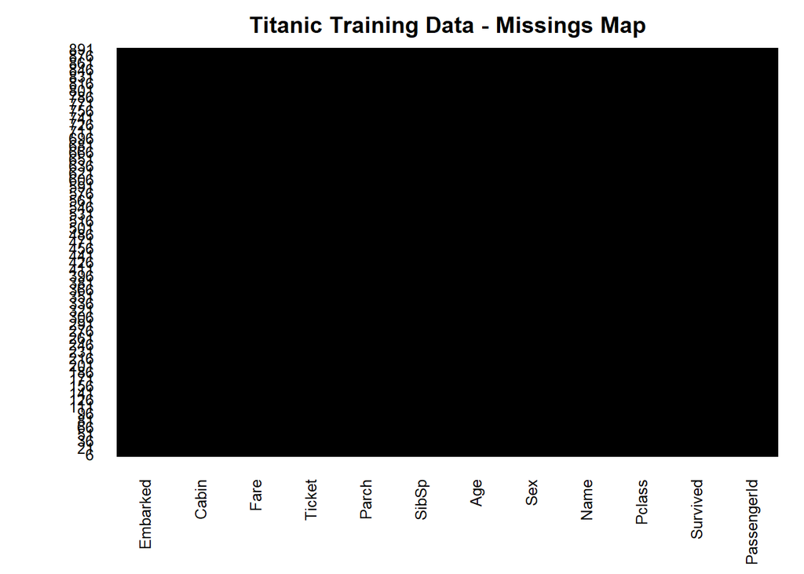

```r
missmap(df.train, main="Titanic Training Data - Missings Map", col=c("yellow", "black"), legend=FALSE)
```

Great let’s continue with building our model!

## Building a Logistic Regression Model

Now it is time to build our model! Let’s begin by doing a final “clean-up” of our data by removing the features we won’t be using and making sure that the features are of the correct data type.

```r
str(df.train)
```

```
## 'data.frame':    891 obs. of  12 variables:
##  $ PassengerId: int  1 2 3 4 5 6 7 8 9 10 ...
##  $ Survived   : int  0 1 1 1 0 0 0 0 1 1 ...
##  $ Pclass     : int  3 1 3 1 3 3 1 3 3 2 ...
##  $ Name       : Factor w/ 891 levels "Abbing, Mr. Anthony",..: 109 191 358 277 16 559 520 629 417 581 ...
##  $ Sex        : Factor w/ 2 levels "female","male": 2 1 1 1 2 2 2 2 1 1 ...
##  $ Age        : num  22 38 26 35 35 24 54 2 27 14 ...
##  $ SibSp      : int  1 1 0 1 0 0 0 3 0 1 ...
##  $ Parch      : int  0 0 0 0 0 0 0 1 2 0 ...
##  $ Ticket     : Factor w/ 681 levels "110152","110413",..: 524 597 670 50 473 276 86 396 345 133 ...
##  $ Fare       : num  7.25 71.28 7.92 53.1 8.05 ...
##  $ Cabin      : Factor w/ 148 levels "","A10","A14",..: 1 83 1 57 1 1 131 1 1 1 ...
##  $ Embarked   : Factor w/ 4 levels "","C","Q","S": 4 2 4 4 4 3 4 4 4 2 ...
```

Let’s remove what we won’t use:

```r
library(dplyr)
df.train <- select(df.train,-PassengerId,-Name,-Ticket,-Cabin)
```

Now let’s set factor columns.

```r
df.train$Survived <- factor(df.train$Survived)
df.train$Pclass <- factor(df.train$Pclass)
df.train$Parch <- factor(df.train$Parch)
df.train$SibSp <- factor(df.train$SibSp)
```

## Train the Model

Now let’s train the model!

```r
log.model <- glm(formula=Survived ~ . , family = binomial(link='logit'),data = df.train)
summary(log.model)
```

```
##
## Call:
## glm(formula = Survived ~ ., family = binomial(link = "logit"),
##     data = df.train)
##
## Deviance Residuals:
##     Min       1Q   Median       3Q      Max
## -2.8158  -0.6134  -0.4138   0.5808   2.4896
##
## Coefficients:
##               Estimate Std. Error z value Pr(>|z|)
## (Intercept)  1.845e+01  1.660e+03   0.011 0.991134
## Pclass2     -1.079e+00  3.092e-01  -3.490 0.000484 ***
## Pclass3     -2.191e+00  3.161e-01  -6.930 4.20e-12 ***
## Sexmale     -2.677e+00  2.040e-01 -13.123  < 2e-16 ***
## Age         -3.971e-02  8.758e-03  -4.534 5.79e-06 ***
## SibSp1       8.135e-02  2.245e-01   0.362 0.717133
## SibSp2      -2.897e-01  5.368e-01  -0.540 0.589361
## SibSp3      -2.241e+00  7.202e-01  -3.111 0.001862 **
## SibSp4      -1.675e+00  7.620e-01  -2.198 0.027954 *
## SibSp5      -1.595e+01  9.588e+02  -0.017 0.986731
## SibSp8      -1.607e+01  7.578e+02  -0.021 0.983077
## Parch1       3.741e-01  2.895e-01   1.292 0.196213
## Parch2       3.862e-02  3.824e-01   0.101 0.919560
## Parch3       3.655e-01  1.056e+00   0.346 0.729318
## Parch4      -1.586e+01  1.055e+03  -0.015 0.988007
## Parch5      -1.152e+00  1.172e+00  -0.983 0.325771
## Parch6      -1.643e+01  2.400e+03  -0.007 0.994536
## Fare         2.109e-03  2.490e-03   0.847 0.397036
## EmbarkedC   -1.458e+01  1.660e+03  -0.009 0.992995
## EmbarkedQ   -1.456e+01  1.660e+03  -0.009 0.993001
## EmbarkedS   -1.486e+01  1.660e+03  -0.009 0.992857
## ---
## Signif. codes:  0 '***' 0.001 '**' 0.01 '*' 0.05 '.' 0.1 ' ' 1
##
## (Dispersion parameter for binomial family taken to be 1)
##
##     Null deviance: 1186.66  on 890  degrees of freedom
## Residual deviance:  763.41  on 870  degrees of freedom
## AIC: 805.41
##
## Number of Fisher Scoring iterations: 15
```

We can see clearly that Sex,Age, and Class are the most significant features. Which makes sense given the women and children first policy.

## Predicting using Test Cases

```r
library(caTools)
set.seed(101)

split = sample.split(df.train$Survived, SplitRatio = 0.70)

final.train = subset(df.train, split == TRUE)
final.test = subset(df.train, split == FALSE)
```

Now let’s rerun our model on only our final training set:

```r
final.log.model <- glm(formula=Survived ~ . , family = binomial(link='logit'),data = final.train)
```

```r
summary(final.log.model)
```

```
##
## Call:
## glm(formula = Survived ~ ., family = binomial(link = "logit"),
##     data = final.train)
##
## Deviance Residuals:
##     Min       1Q   Median       3Q      Max
## -2.8288  -0.5607  -0.4096   0.6174   2.4898
##
## Coefficients:
##               Estimate Std. Error z value Pr(>|z|)
## (Intercept)  1.777e+01  2.400e+03   0.007 0.994091
## Pclass2     -1.230e+00  3.814e-01  -3.225 0.001261 **
## Pclass3     -2.160e+00  3.841e-01  -5.624 1.87e-08 ***
## Sexmale     -2.660e+00  2.467e-01 -10.782  < 2e-16 ***
## Age         -3.831e-02  1.034e-02  -3.705 0.000212 ***
## SibSp1      -2.114e-02  2.755e-01  -0.077 0.938836
## SibSp2      -4.000e-01  6.463e-01  -0.619 0.536028
## SibSp3      -2.324e+00  8.994e-01  -2.584 0.009765 **
## SibSp4      -1.196e+00  8.302e-01  -1.440 0.149839
## SibSp5      -1.603e+01  9.592e+02  -0.017 0.986666
## SibSp8      -1.633e+01  1.004e+03  -0.016 0.987019
## Parch1       7.290e-01  3.545e-01   2.056 0.039771 *
## Parch2       1.406e-01  4.504e-01   0.312 0.754892
## Parch3       7.919e-01  1.229e+00   0.645 0.519226
## Parch4      -1.498e+01  1.552e+03  -0.010 0.992300
## Parch5      -9.772e-03  1.378e+00  -0.007 0.994343
## Parch6      -1.635e+01  2.400e+03  -0.007 0.994563
## Fare         3.128e-03  3.091e-03   1.012 0.311605
## EmbarkedC   -1.398e+01  2.400e+03  -0.006 0.995353
## EmbarkedQ   -1.387e+01  2.400e+03  -0.006 0.995386
## EmbarkedS   -1.431e+01  2.400e+03  -0.006 0.995243
## ---
## Signif. codes:  0 '***' 0.001 '**' 0.01 '*' 0.05 '.' 0.1 ' ' 1
##
## (Dispersion parameter for binomial family taken to be 1)
##
##     Null deviance: 829.60  on 622  degrees of freedom
## Residual deviance: 530.63  on 602  degrees of freedom
## AIC: 572.63
##
## Number of Fisher Scoring iterations: 15
```

Now let’s check our prediction accuracy!

```r
fitted.probabilities <- predict(final.log.model,newdata=final.test,type='response')
```

```r
fitted.results <- ifelse(fitted.probabilities > 0.5,1,0)
```

```r
misClasificError <- mean(fitted.results != final.test$Survived)
print(paste('Accuracy',1-misClasificError))
```

```
## [1] "Accuracy 0.798507462686567"
```

Looks like we were able to achieve around 80% accuracy, where as random guessing would have just been 50% accuracy. Let’s see the confusion matrix:

```r
table(final.test$Survived, fitted.probabilities > 0.5)
```

```
##
##     FALSE TRUE
##   0   140   25
##   1    29   74
```